# Untitled

2024-07-06

# 1. Import library

```r
library(boot)
library(tidyverse)
library(matrixStats)
library(lubridate)
library(janitor)
```

```r
library(ggplot2)
library(corrplot)
library(dplyr)
library(splines2)
library(mgcv)
library(mgcViz)
library(leaps)
library(gridExtra)
library(grid)
library(MASS)
library(leaps)
library(lmPerm)
library(corrplot)
library(splines2)
library(DataExplorer)
library(caret)
library(mgcv)
library(mgcViz)
library(splines)
library(lmPerm)
library(readr)
library(fastDummies)
```

# 2. Read data

```r
locale=locale(encoding="latin1")
data <- read_csv("SeoulBikeData.csv", locale = locale)
head(data)
```

```
## # A tibble: 6 × 14
##   Date       `Rented Bike Count`  Hour `Temperature(°C)` `Humidity(%)`
##   <chr>                    <dbl> <dbl>             <dbl>         <dbl>
## 1 01/12/2017                 254     0              -5.2            37
## 2 01/12/2017                 204     1              -5.5            38
## 3 01/12/2017                 173     2              -6              39
## 4 01/12/2017                 107     3              -6.2            40
## 5 01/12/2017                  78     4              -6              36
## 6 01/12/2017                 100     5              -6.4            37
## # ℹ 9 more variables: `Wind speed (m/s)` <dbl>, `Visibility (10m)` <dbl>,
## #   `Dew point temperature(°C)` <dbl>, `Solar Radiation (MJ/m2)` <dbl>,
## #   `Rainfall(mm)` <dbl>, `Snowfall (cm)` <dbl>, Seasons <chr>, Holiday <chr>,
## #   `Functioning Day` <chr>
```

```r
data <- data |> janitor::clean_names()
glimpse(data)
```

```
## Rows: 8,760
## Columns: 14
## $ date                    <chr> "01/12/2017", "01/12/2017", "01/12/2017", "01/…
## $ rented_bike_count       <dbl> 254, 204, 173, 107, 78, 100, 181, 460, 930, 49…
## $ hour                    <dbl> 0, 1, 2, 3, 4, 5, 6, 7, 8, 9, 10, 11, 12, 13, …
## $ temperature_c           <dbl> -5.2, -5.5, -6.0, -6.2, -6.0, -6.4, -6.6, -7.4…
## $ humidity_percent        <dbl> 37, 38, 39, 40, 36, 37, 35, 38, 37, 27, 24, 21…
## $ wind_speed_m_s          <dbl> 2.2, 0.8, 1.0, 0.9, 2.3, 1.5, 1.3, 0.9, 1.1, 0…
## $ visibility_10m          <dbl> 2000, 2000, 2000, 2000, 2000, 2000, 2000, 2000…
## $ dew_point_temperature_c <dbl> -17.6, -17.6, -17.7, -17.6, -18.6, -18.7, -19.…
## $ solar_radiation_mj_m2   <dbl> 0.00, 0.00, 0.00, 0.00, 0.00, 0.00, 0.00, 0.00…
## $ rainfall_mm             <dbl> 0, 0, 0, 0, 0, 0, 0, 0, 0, 0, 0, 0, 0, 0, 0, 0…
## $ snowfall_cm             <dbl> 0, 0, 0, 0, 0, 0, 0, 0, 0, 0, 0, 0, 0, 0, 0, 0…
## $ seasons                 <chr> "Winter", "Winter", "Winter", "Winter", "Winte…
## $ holiday                 <chr> "No Holiday", "No Holiday", "No Holiday", "No …
## $ functioning_day         <chr> "Yes", "Yes", "Yes", "Yes", "Yes", "Yes", "Yes…
```

# 3. Prosessing Data

# 4. EDA.

## 4.1 Bảng tổng hợp dữ liệu

```r
summary(data)
```

```
##      date           rented_bike_count      hour       temperature_c
##  Length:8760        Min.   :   0.0    Min.   : 0.00   Min.   :-17.80
##  Class :character   1st Qu.: 191.0    1st Qu.: 5.75   1st Qu.:  3.50
##  Mode  :character   Median : 504.5    Median :11.50   Median : 13.70
##                     Mean   : 704.6    Mean   :11.50   Mean   : 12.88
##                     3rd Qu.:1065.2    3rd Qu.:17.25   3rd Qu.: 22.50
##                     Max.   :3556.0    Max.   :23.00   Max.   : 39.40
##  humidity_percent wind_speed_m_s  visibility_10m dew_point_temperature_c
##  Min.   : 0.00    Min.   :0.000   Min.   :  27   Min.   :-30.600
##  1st Qu.:42.00    1st Qu.:0.900   1st Qu.: 940   1st Qu.: -4.700
##  Median :57.00    Median :1.500   Median :1698   Median :  5.100
##  Mean   :58.23    Mean   :1.725   Mean   :1437   Mean   :  4.074
##  3rd Qu.:74.00    3rd Qu.:2.300   3rd Qu.:2000   3rd Qu.: 14.800
##  Max.   :98.00    Max.   :7.400   Max.   :2000   Max.   : 27.200
##  solar_radiation_mj_m2  rainfall_mm       snowfall_cm        seasons
##  Min.   :0.0000        Min.   : 0.0000   Min.   :0.00000   Length:8760
##  1st Qu.:0.0000        1st Qu.: 0.0000   1st Qu.:0.00000   Class :character
##  Median :0.0100        Median : 0.0000   Median :0.00000   Mode  :character
##  Mean   :0.5691        Mean   : 0.1487   Mean   :0.07507
##  3rd Qu.:0.9300        3rd Qu.: 0.0000   3rd Qu.:0.00000
##  Max.   :3.5200        Max.   :35.0000   Max.   :8.80000
##    holiday          functioning_day
##  Length:8760        Length:8760
##  Class :character   Class :character
##  Mode  :character   Mode  :character
##
##
##
```

## 4.2 Xử lí dữ liệu.

### 4.2.1 Kiểm tra tổng thể dữ liệu.

```r
# Hàm để lấy thông tin dữ liệu bao gồm loại dữ liệu, giá trị duy nhất, và giá trị null
datainfo <- function(data) {
  # Tạo một khung dữ liệu để lưu trữ thông tin
  temp_ps <- data.frame(matrix(ncol = 6, nrow = ncol(data)))
  colnames(temp_ps) <- c("Column_Name", "DataType", "Non_null_Values", "Unique_Values", "NaN_Values_Percentage", "Duplicates")

  # Điền thông tin vào khung dữ liệu
  temp_ps$Column_Name <- colnames(data)  # Lấy tên các cột
  temp_ps$DataType <- sapply(data, class)
  # Lấy loại dữ liệu sử dụng sapply
  temp_ps$Non_null_Values <- sapply(data, function(x) sum(!is.na(x)))
  # Đếm số giá trị không null sử dụng sapply và is.na
  temp_ps$Unique_Values <- sapply(data, function(x) length(unique(na.omit(x))))
  # Đếm số giá trị duy nhất loại bỏ các giá trị NA
  temp_ps$NaN_Values <- sapply(data, function(x) sum(is.na(x)))
  # Đếm số giá trị null sử dụng sapply và is.na
  temp_ps$NaN_Values_Percentage <- (temp_ps$NaN_Values / nrow(data)) * 100
  # Tính tỷ lệ phần trăm của các giá trị null

  # Đếm số lượng bản ghi bị trùng lặp trong dữ liệu
  temp_ps$Duplicates <- sum(duplicated(data))

  # Trả về khung dữ liệu chứa thông tin
  return(temp_ps)
}
data_info <- datainfo(data)
print(data_info)
```

```
##                Column_Name  DataType Non_null_Values Unique_Values
## 1                     date character            8760           365
## 2        rented_bike_count   numeric            8760          2166
## 3                     hour   numeric            8760            24
## 4            temperature_c   numeric            8760           546
## 5         humidity_percent   numeric            8760            90
## 6           wind_speed_m_s   numeric            8760            65
## 7           visibility_10m   numeric            8760          1789
## 8  dew_point_temperature_c   numeric            8760           556
## 9    solar_radiation_mj_m2   numeric            8760           345
## 10             rainfall_mm   numeric            8760            61
## 11             snowfall_cm   numeric            8760            51
## 12                 seasons character            8760             4
## 13                 holiday character            8760             2
## 14         functioning_day character            8760             2
##    NaN_Values_Percentage Duplicates NaN_Values
## 1                      0          0          0
## 2                      0          0          0
## 3                      0          0          0
## 4                      0          0          0
## 5                      0          0          0
## 6                      0          0          0
## 7                      0          0          0
## 8                      0          0          0
## 9                      0          0          0
## 10                     0          0          0
## 11                     0          0          0
## 12                     0          0          0
## 13                     0          0          0
## 14                     0          0          0
```

=> Bộ dữ liệu không chứa NaN

### 4.2.2 Kiểm tra hàm functioning_day với rented_bike_coun

```r
result <- data %>%
  group_by(functioning_day) %>%
  summarise(rented_bike_count = sum(rented_bike_count, na.rm = TRUE)) %>%
  arrange(desc(rented_bike_count)) %>%
  ungroup()
print(result)
```

```
## # A tibble: 2 × 2
##   functioning_day rented_bike_count
##   <chr>                       <dbl>
## 1 Yes                       6172314
## 2 No                              0
```

```r
summary(factor(data$functioning_day))
```

```
##   No  Yes
##  295 8465
```

```r
data <- data %>%
  filter(functioning_day != 0) %>% dplyr::select(-functioning_day)
```

### 4.2.3 Chuyển đổi kiểu dữ liệu cho các biến holiday, seasons.

```r
  data <- data |> mutate(
  holiday = as.factor(holiday),
  seasons = as.factor(seasons)
)
```

### 4.2.4 Tách thời gian thành ngày, tháng, năm và thêm cột ngày trong tuần.

```r
data <- data %>%
  mutate(
    Date = dmy(date),
    # Chuyển đổi cột 'date' sang định dạng ngày tháng
    year = year(Date),
    month = month(Date),
    day = day(Date)
  )
# Loại bỏ cột 'Date'
data <- subset(data, select = -c(Date))
# Tạo cột day bằng cách kết hợp year, month và day
data$full_date <- as.Date(with(data, paste(year, month, day, sep = "-")), format = "%Y-%m-%d")

# Thêm cột day_of_week dựa trên cột full_date
data$day_of_week <- weekdays(data$full_date)

# Loại bỏ cột 'full_date'
data <- subset(data, select = -c(full_date))

# Hiển thị kết quả
print(head(data))
```

```
## # A tibble: 6 × 17
##   date     rented_bike_count  hour temperature_c humidity_percent wind_speed_m_s
##   <chr>                <dbl> <dbl>         <dbl>            <dbl>          <dbl>
## 1 01/12/2…               254     0          -5.2               37            2.2
## 2 01/12/2…               204     1          -5.5               38            0.8
## 3 01/12/2…               173     2          -6                 39            1
## 4 01/12/2…               107     3          -6.2               40            0.9
## 5 01/12/2…                78     4          -6                 36            2.3
## 6 01/12/2…               100     5          -6.4               37            1.5
## # ℹ 11 more variables: visibility_10m <dbl>, dew_point_temperature_c <dbl>,
## #   solar_radiation_mj_m2 <dbl>, rainfall_mm <dbl>, snowfall_cm <dbl>,
## #   seasons <fct>, holiday <fct>, year <dbl>, month <dbl>, day <int>,
## #   day_of_week <chr>
```

## 4.3 Trực quan dữ liệu.

### 4.3.1 Vẽ biểu đồ boxplot nhằm xem xét phân phối của số lượng xe đạp được thuê (rented_bike_count) vào từng giờ trong ngày (hour)

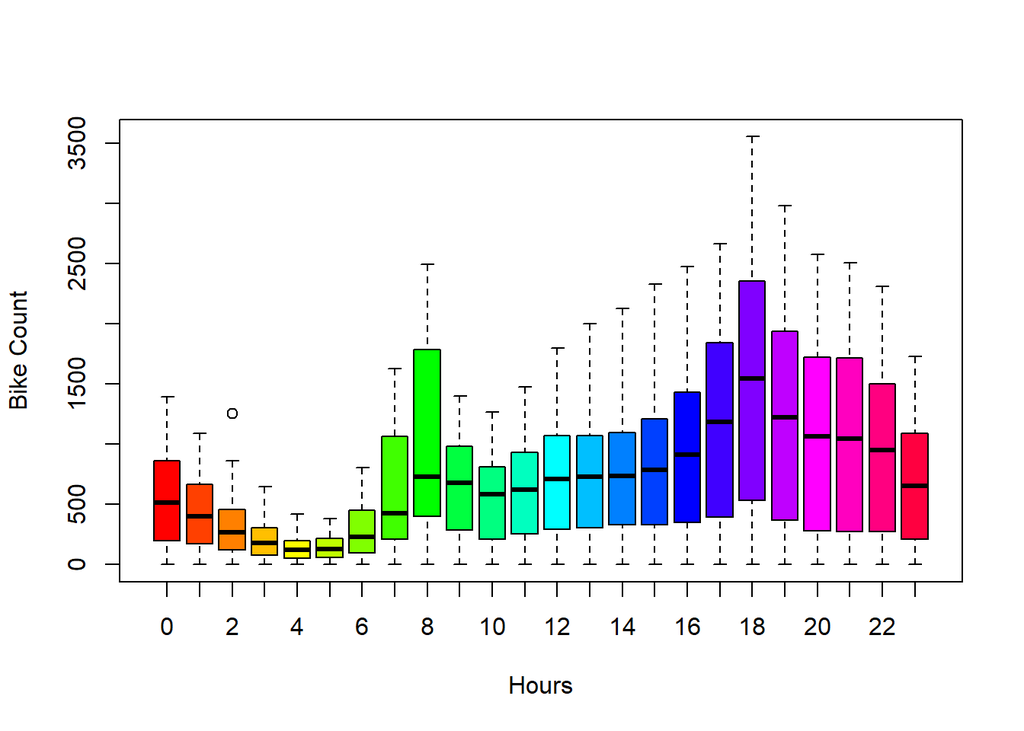

```r
# Vẽ biểu đồ boxplot
boxplot(data$rented_bike_count ~ data$hour,
        xlab = "Hours",
        ylab = "Bike Count",
        col = rainbow(length(unique(data$hour))))
```

### 4.3.2 Vẽ biểu đồ thanh cho số lượng xe đạp thuê theo ngày trong tuần.

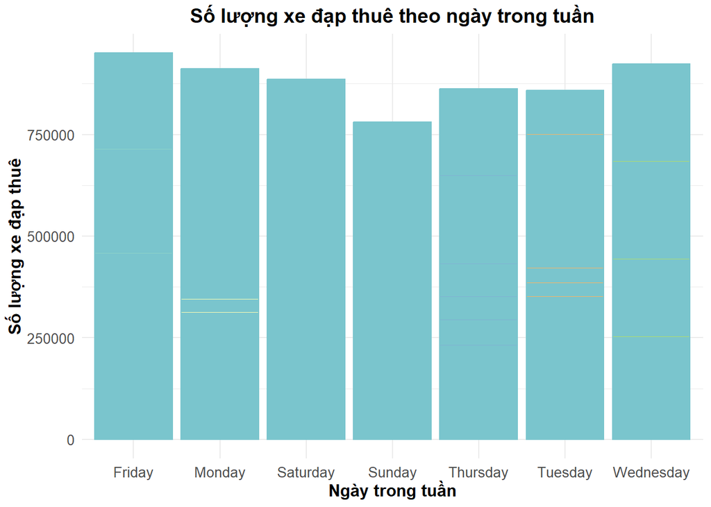

```r
# Biểu đồ thanh cho số lượng xe đạp thuê theo ngày trong tuần
ggplot(data, aes(x = day_of_week, y = rented_bike_count, fill = day_of_week)) +
  geom_bar(stat = "identity", color = "#7AC5CD") +
  labs(
    title = "Số lượng xe đạp thuê theo ngày trong tuần",
    x = "Ngày trong tuần",
    y = "Số lượng xe đạp thuê"
  ) +
  theme_minimal() +
  theme(
    plot.title = element_text(size = 14, face = "bold", hjust = 0.5),
    axis.title.x = element_text(size = 12, face = "bold"),
    axis.title.y = element_text(size = 12, face = "bold"),
    axis.text.x = element_text(size = 10),
    axis.text.y = element_text(size = 10),
    legend.position = "none"
  ) + scale_fill_brewer(palette = "Set3")
```

Tương tự cho seasons và holiday

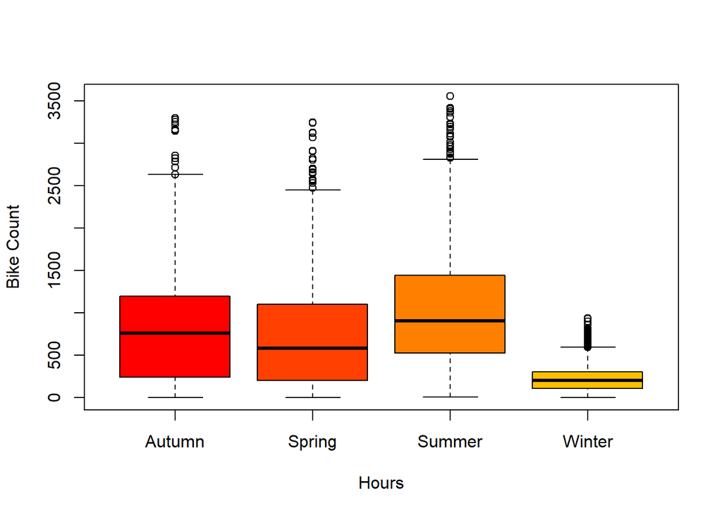

```r
# Vẽ biểu đồ boxplot
boxplot(data$rented_bike_count ~ data$seasons,
        xlab = "Hours",
        ylab = "Bike Count",
        col = rainbow(length(unique(data$hour))))
```

=> **Nhận xét**: Ta có thể thấy rằng trong những thời điểm thời tiết tốt hơn như mùa hè, mọi người thường thích đạp xe hơn và vào mùa đông xe đạp được thuê với giá thấp nhất với số lượng nhu cầu thấp hơn 500 chiếc. Điều này có thể là do thời tiết lạnh cũng như tuyết trong mùa đông. Có một số ngoại lệ với mật độ cao hơn các mùa còn lại khi nhu cầu xe đạp trong Mùa đông là trên 500. Đây có thể là một số lý do cơ bản chẳng hạn như ngày có thời tiết tốt hơn những ngày khác trong mùa đông. + Vào mùa thu, nhu cầu xe đạp cao hơn mùa xuân mặc dù chúng tôi dự kiến nhu cầu vào mùa xuân sẽ cao hơn mùa thu. Điều này có thể là do mùa Xuân có nhiều ngày mưa hơn mùa Thu.

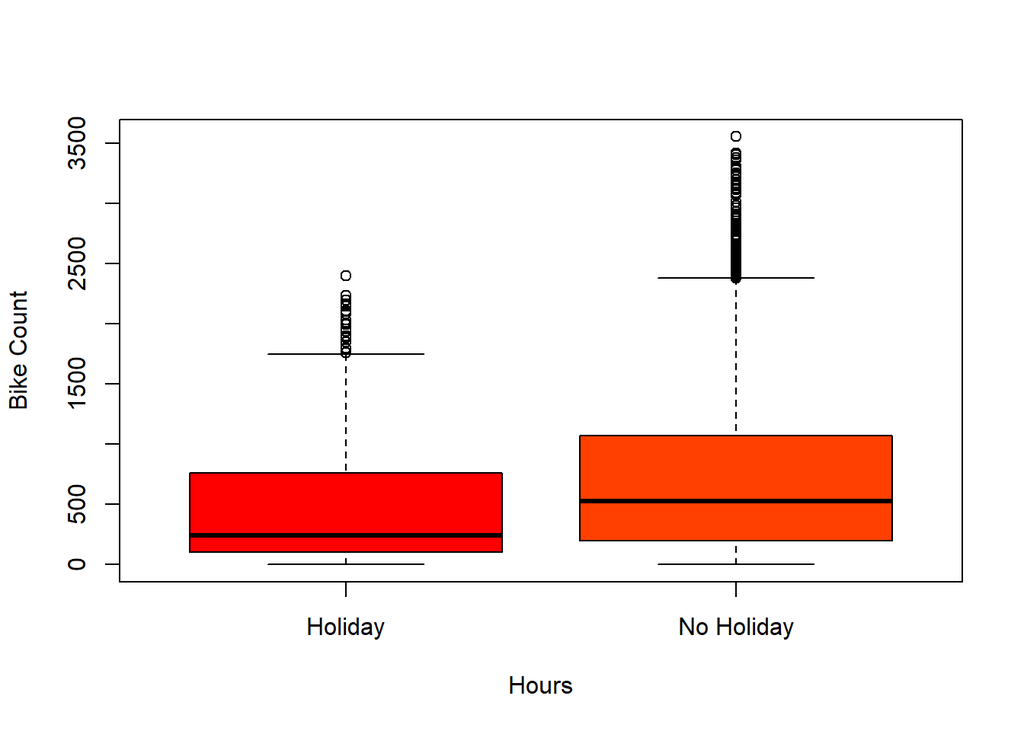

```r
# Vẽ biểu đồ boxplot
boxplot(data$rented_bike_count ~ data$holiday,
        xlab = "Hours",
        ylab = "Bike Count",
        col = rainbow(length(unique(data$hour))))
```

=> **Nhận xét**: Ta có thấy rằng nhu cầu về xe đạp cao hơn vào những ngày không phải ngày nghỉ lễ, điều đó có nghĩa là hầu hết người dùng có thể thuê xe đạp vì những lý do khác ngoài mục đích giải trí.

### 4.3.3 Xem xét số lượng xe đạp thuê theo nhiệt độ để thấy được ảnh hưởng của thời tiết đến nhu cầu thuê xe đạp.

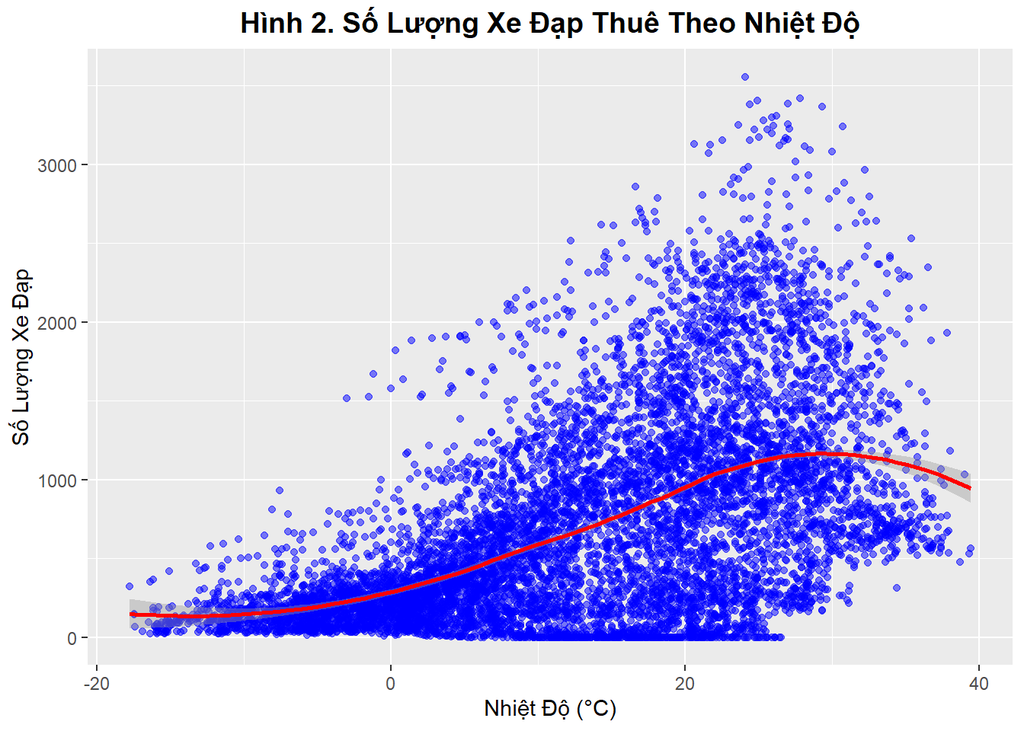

```r
ggplot(data, aes(x = temperature_c, y = rented_bike_count)) +
  geom_point(alpha = 0.5, color = "blue") +
  geom_smooth(method = "loess", color = "red") +
  ggtitle("Hình 2. Số Lượng Xe Đạp Thuê Theo Nhiệt Độ") +
  xlab("Nhiệt Độ (°C)") +
  ylab("Số Lượng Xe Đạp")+
  theme(plot.title = element_text(size = 14, face = "bold", hjust = 0.5))
```

### 4.3.4 Correlation Matrix

[figure not shown]

```r
numeric_data <- data[, sapply(data, is.numeric)]
correlation_matrix <- cor(numeric_data)

# Load the corrplot package
library(corrplot)

# Plot the correlation matrix
corrplot(correlation_matrix, method = "shade",tl.cex = 0.5)
```

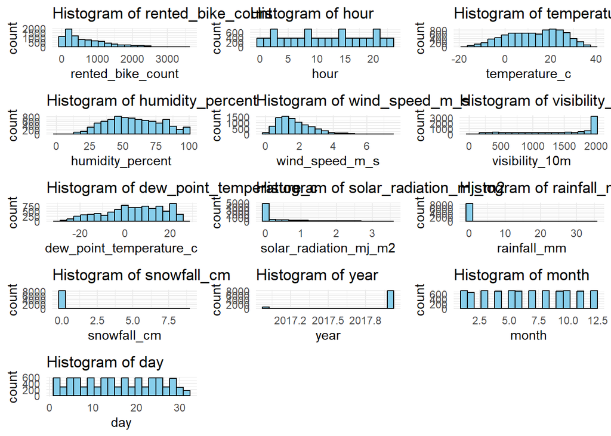

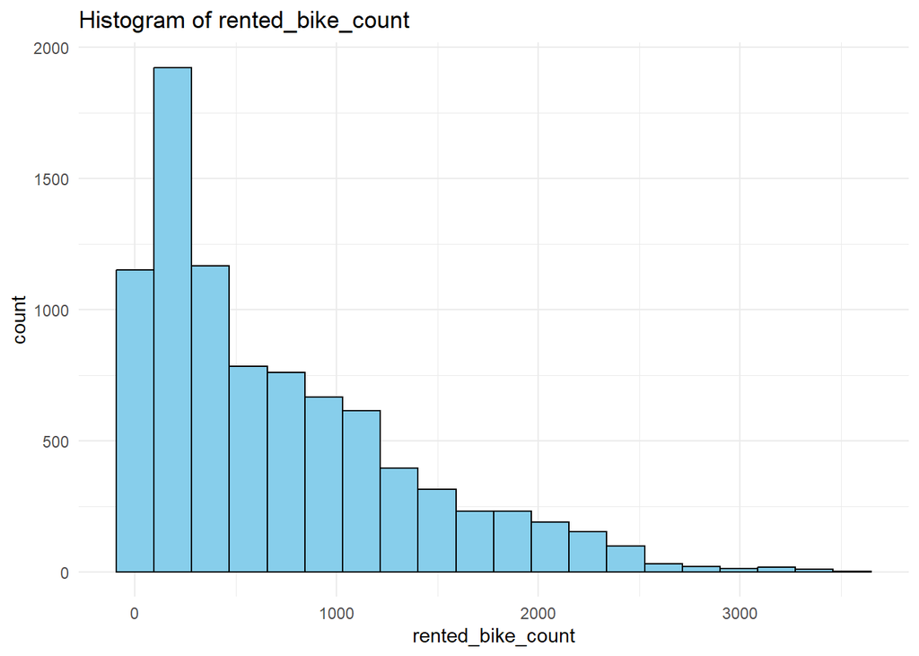

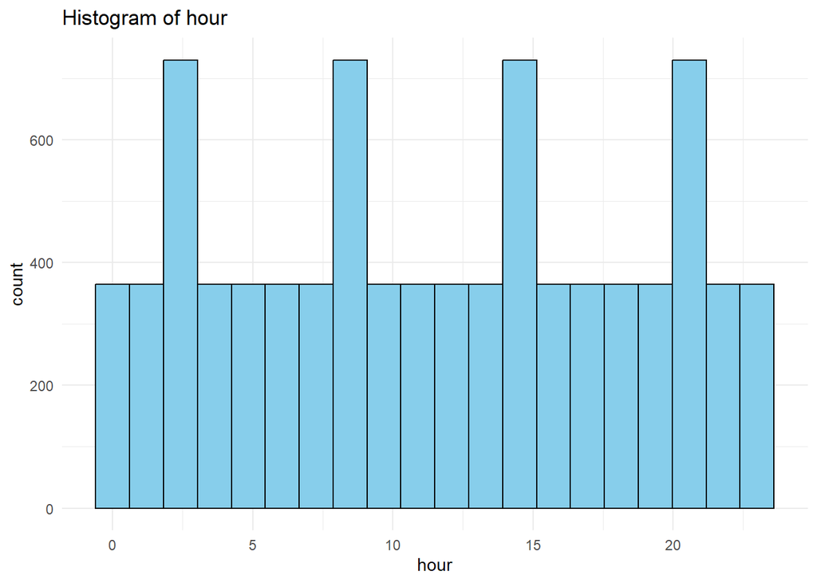

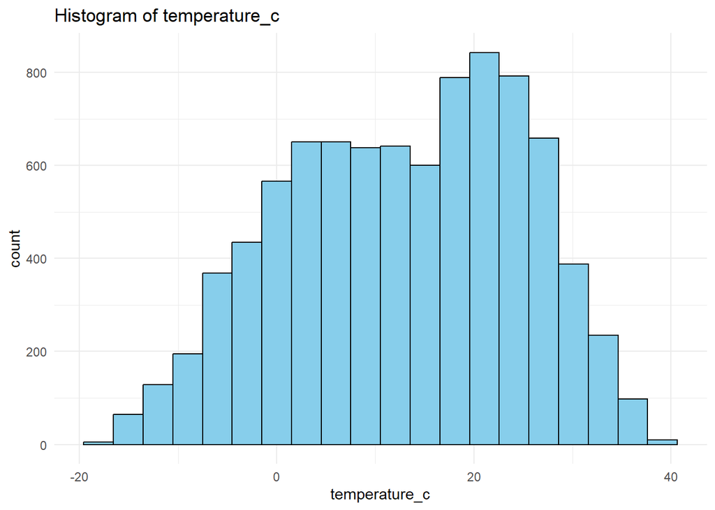

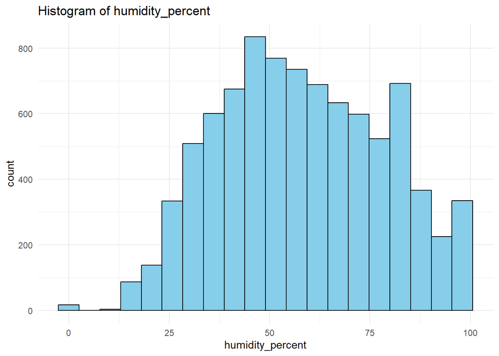

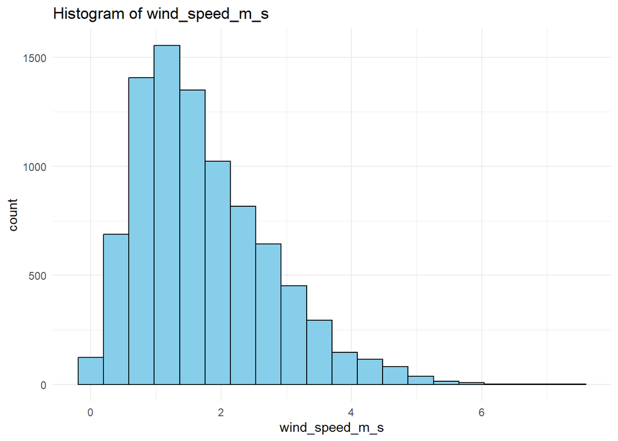

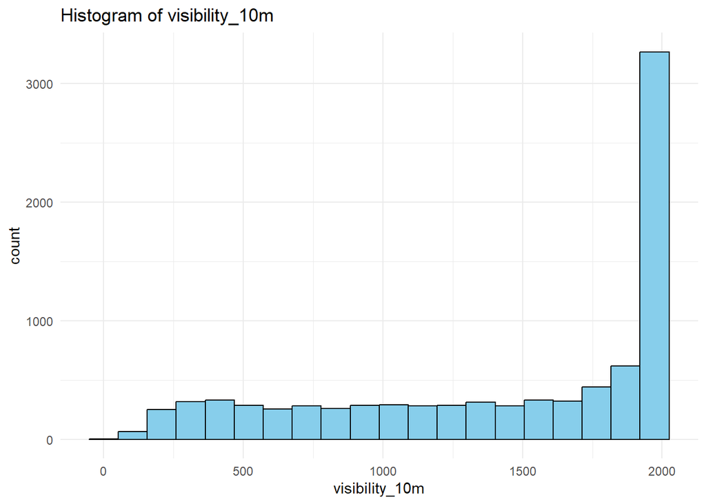

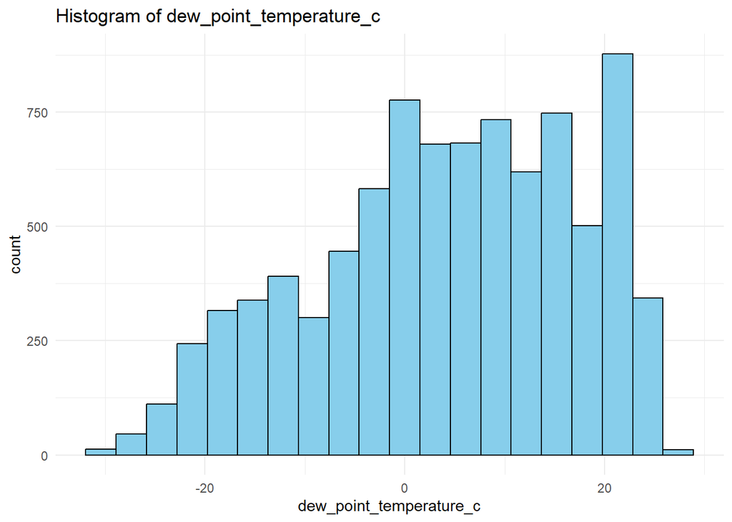

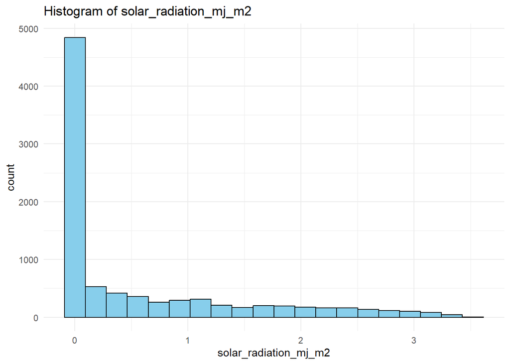

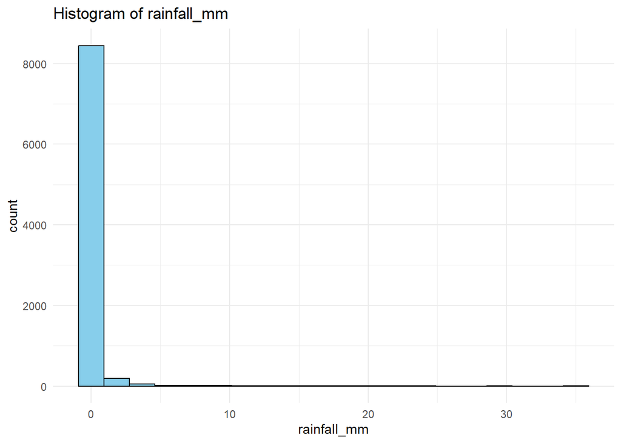

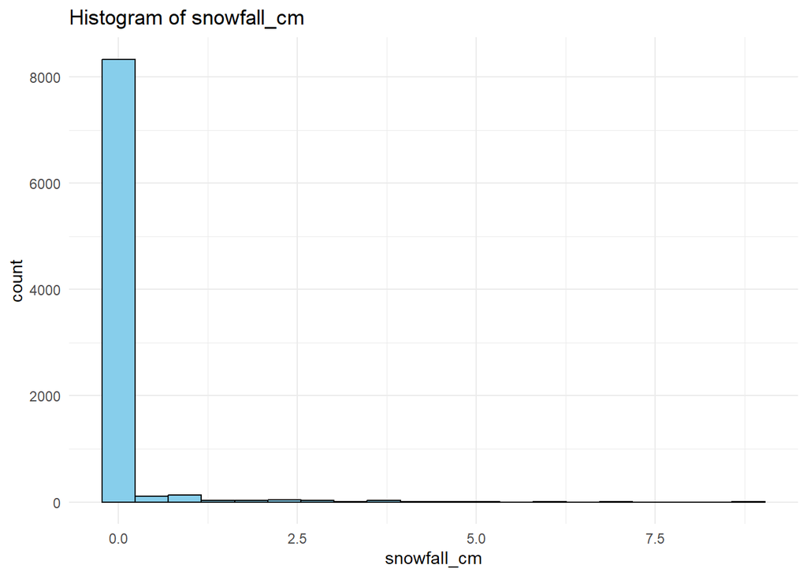

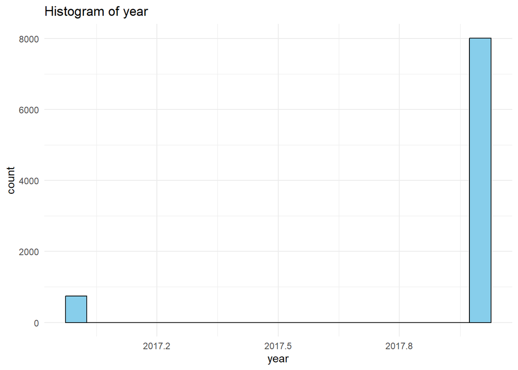

[2 more figures not shown]

```r
# Function to create histograms
multi.hist <- function(data) {
  # Initialize an empty list to store plots
  plots <- list()

  # Loop through each numeric variable
  for (col in names(data)) {
    # Create histogram plot
    hist_plot <- ggplot(data, aes_string(x = col)) +
      geom_histogram(fill = "skyblue", color = "black", bins = 20) +  # Customize fill and color
      ggtitle(paste("Histogram of", col)) +
      theme_minimal()

    # Add the plot to the list
    plots[[col]] <- hist_plot
  }

  # Arrange plots in a grid
  grid.arrange(grobs = plots, ncol = 3)  # Adjust ncol as needed

  # Return the list of plots (optional)
  return(plots)
}

# Call the function with numeric columns of 'bike'
multi.hist(data[, sapply(data, is.numeric)])
```

## 4.4 Bảng Tổng hợp theo Giờ trong Ngày

```r
summary_hour <- data %>%
  group_by(hour) %>%
  summarize(
    total_bike_count = sum(rented_bike_count),
    mean_bike_count = mean(rented_bike_count),
    median_bike_count = median(rented_bike_count),
    max_bike_count = max(rented_bike_count),
    min_bike_count = min(rented_bike_count)
  )
print(summary_hour)
```

```
## # A tibble: 24 × 6
##     hour total_bike_count mean_bike_count median_bike_count max_bike_count
##    <dbl>            <dbl>           <dbl>             <dbl>          <dbl>
##  1     0           197633            541.               513           1394
##  2     1           155557            426.               401           1088
##  3     2           110095            302.               265           1254
##  4     3            74216            203.               176            644
##  5     4            48396            133.               119            421
##  6     5            50765            139.               129            383
##  7     6           104961            288.               232            807
##  8     7           221192            606.               426           1629
##  9     8           370731           1016.               728           2495
## 10     9           235784            646.               680           1401
## # ℹ 14 more rows
## # ℹ 1 more variable: min_bike_count <dbl>
```

=> **Nhận xét**: Bảng cho biết tổng số, trung bình, trung vị, giá trị lớn nhất và nhỏ nhất của số lượng xe đạp thuê theo từng giờ trong ngày. Giúp xác định giờ cao điểm và giờ thấp điểm.

### 4.4.1 Bảng Tổng hợp theo Ngày trong Tuần

```r
data$day_of_week <- weekdays(as.Date(data$date, format="%d/%m/%Y"))

summary_day_of_week <- data %>%
  group_by(day_of_week) %>%
  summarize(
    total_bike_count = sum(rented_bike_count),
    mean_bike_count = mean(rented_bike_count),
    median_bike_count = median(rented_bike_count),
    max_bike_count = max(rented_bike_count),
    min_bike_count = min(rented_bike_count)
  )

print(summary_day_of_week)
```

```
## # A tibble: 7 × 6
##   day_of_week total_bike_count mean_bike_count median_bike_count max_bike_count
##   <chr>                  <dbl>           <dbl>             <dbl>          <dbl>
## 1 Friday                950334            747.              566            3365
## 2 Monday                911743            731.              533            3380
## 3 Saturday              885492            710.              519            2497
## 4 Sunday                780194            625.              406            2514
## 5 Thursday              861999            691.              495            3418
## 6 Tuesday               858596            688.              486.           3556
## 7 Wednesday             923956            740.              536.           3384
## # ℹ 1 more variable: min_bike_count <dbl>
```

=> Kết quả sẽ cho thấy sự khác biệt về nhu cầu thuê xe đạp giữa các ngày trong tuần.

### 4.4.2 Bảng Tổng hợp theo Mùa

```r
summary_season <- data %>%
  group_by(seasons) %>%
  summarize(
    total_bike_count = sum(rented_bike_count),
    mean_bike_count = mean(rented_bike_count),
    median_bike_count = median(rented_bike_count),
    max_bike_count = max(rented_bike_count),
    min_bike_count = min(rented_bike_count)
  )

print(summary_season)
```

```
## # A tibble: 4 × 6
##   seasons total_bike_count mean_bike_count median_bike_count max_bike_count
##   <fct>              <dbl>           <dbl>             <dbl>          <dbl>
## 1 Autumn           1790002            820.              764.           3298
## 2 Spring           1611909            730.              583            3251
## 3 Summer           2283234           1034.              906.           3556
## 4 Winter            487169            226.              203             937
## # ℹ 1 more variable: min_bike_count <dbl>
```

=> Kết quả sẽ cho thấy sự khác biệt về nhu cầu thuê xe đạp giữa các mùa. Ví dụ, mùa hè có thể có nhu cầu cao hơn mùa đông.

### 4.4.3 Bảng Tổng hợp theo Ngày Lễ

```r
summary_holiday <- data %>%
  group_by(holiday) %>%
  summarize(
    total_bike_count = sum(rented_bike_count),
    mean_bike_count = mean(rented_bike_count),
    median_bike_count = median(rented_bike_count),
    max_bike_count = max(rented_bike_count),
    min_bike_count = min(rented_bike_count)
  )

print(summary_holiday)
```

```
## # A tibble: 2 × 6
##   holiday    total_bike_count mean_bike_count median_bike_count max_bike_count
##   <fct>                 <dbl>           <dbl>             <dbl>          <dbl>
## 1 Holiday              215895            500.              240            2400
## 2 No Holiday          5956419            715.              524.           3556
## # ℹ 1 more variable: min_bike_count <dbl>
```

Kết quả sẽ cho thấy sự khác biệt về nhu cầu thuê xe đạp giữa các ngày lễ và ngày thường.

### 4.4.4 Bảng Tổng hợp theo Nhiệt độ

```r
data$temp_range <- cut(data$temperature_c, breaks = seq(floor(min(data$temperature_c)), ceiling(max(data$temperature_c)), by = 5))

summary_temp <- data %>%
  group_by(temp_range) %>%
  summarize(
    total_bike_count = sum(rented_bike_count),
    mean_bike_count = mean(rented_bike_count),
    median_bike_count = median(rented_bike_count),
    max_bike_count = max(rented_bike_count),
    min_bike_count = min(rented_bike_count)
  )

print(summary_temp)
```

```
## # A tibble: 12 × 6
##    temp_range total_bike_count mean_bike_count median_bike_count max_bike_count
##    <fct>                 <dbl>           <dbl>             <dbl>          <dbl>
##  1 (-18,-13]             10113            119.               94             469
##  2 (-13,-8]              42724            161.              136.            812
##  3 (-8,-3]              123377            195.              168.           1516
##  4 (-3,2]               227180            255.              216            1883
##  5 (2,7]                440565            406.              340            2000
##  6 (7,12]               627171            578.              520            2254
##  7 (12,17]              775206            745.              736            2857
##  8 (17,22]             1245008            904.              873            3130
##  9 (22,27]             1421600           1181.             1100            3556
## 10 (27,32]              937282           1188.             1078            3418
## 11 (32,37]              305711           1076.              821            2965
## 12 <NA>                  16377            780.              665            1929
## # ℹ 1 more variable: min_bike_count <dbl>
```

Kết quả sẽ cho thấy mối quan hệ giữa nhiệt độ và số lượng xe đạp thuê. Điều này có thể giúp dự đoán nhu cầu thuê xe đạp dựa trên dự báo thời tiết.

=> Những bảng tổng hợp và biểu đồ này sẽ cung cấp cái nhìn tổng quan và chi tiết về các yếu tố ảnh hưởng đến nhu cầu thuê xe đạp, giúp đưa ra các quyết định quản lý và phát triển dịch vụ hiệu quả hơn.

# 5. A/B Testing

## 5.1 Phân loại dữ liệu thành hai nhóm: Holiday và No Holiday

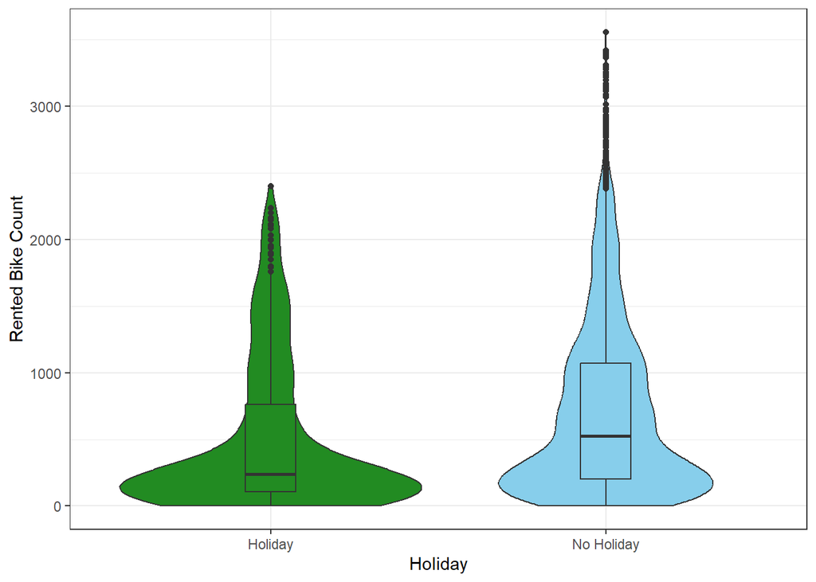

```r
ggplot(data, aes(x = holiday, y = rented_bike_count, fill = holiday)) +
  geom_violin() +
  geom_boxplot(width = 0.15) +
  scale_fill_manual(breaks = c("Holiday", "No Holiday"),
                    values = c("forestgreen", "skyblue")) +
  labs(x = "Holiday", y = "Rented Bike Count") +
  theme_bw() +
  theme(legend.position = "none")
```

**Nhóm A:** Dữ liệu vào các ngày không phải là ngày nghỉ lễ.

**Nhóm B:** Dữ liệu vào các ngày nghỉ lễ.

Thông qua bảng tổng hợp và biểu đổ violin, một giả định có thể là “Số lượng sử dụng xe đạp vào những ngày No Holiday là nhiều hơn những ngày Holiday”.

```r
summary_data <- data %>%
  group_by(holiday) %>%
  summarise(
    n = n(),
    mean_rented_bike_count = mean(rented_bike_count, na.rm = TRUE),
    sd_rented_bike_count = sd(rented_bike_count, na.rm = TRUE)
  )
print(summary_data)
```

```
## # A tibble: 2 × 4
##   holiday        n mean_rented_bike_count sd_rented_bike_count
##   <fct>      <int>                  <dbl>                <dbl>
## 1 Holiday      432                   500.                 571.
## 2 No Holiday  8328                   715.                 647.
```

```r
perm_fun <- function(x, nA, nB, R) {
n <- nA + nB
mean_diff <- numeric(R)
for (i in 1:R){
idx_a <- sample(x = 1:n, size = nA)
idx_b <- setdiff(x = 1:n, y = idx_a)
mean_diff[i] <- mean(x[idx_a]) - mean(x[idx_b])
}
return(mean_diff)
}
set.seed(42)
diff_mean_perm <- perm_fun(data$rented_bike_count, nA = 8328 , nB = 432  , R = 10000)
mean_a <- mean(data$rented_bike_count[data$holiday == 'Holiday'])
mean_b <- mean(data$rented_bike_count [data$holiday == 'No Holiday'])
mean(diff_mean_perm < (mean_a - mean_b))
```

```
## [1] 0
```

## 5.2 Season

```r
# Thực hiện nhóm dữ liệu theo 'seasons' và tính toán các giá trị
summary_seasons <- data %>%
  group_by(seasons) %>%
  summarise(
    n = n(),
    mean_rented_bike_count = mean(rented_bike_count, na.rm = TRUE),
    sd_rented_bike_count = sd(rented_bike_count, na.rm = TRUE)
  )
print(summary_seasons)
```

```
## # A tibble: 4 × 4
##   seasons     n mean_rented_bike_count sd_rented_bike_count
##   <fct>   <int>                  <dbl>                <dbl>
## 1 Autumn   2184                   820.                 651.
## 2 Spring   2208                   730.                 622.
## 3 Summer   2208                  1034.                 690.
## 4 Winter   2160                   226.                 150.
```

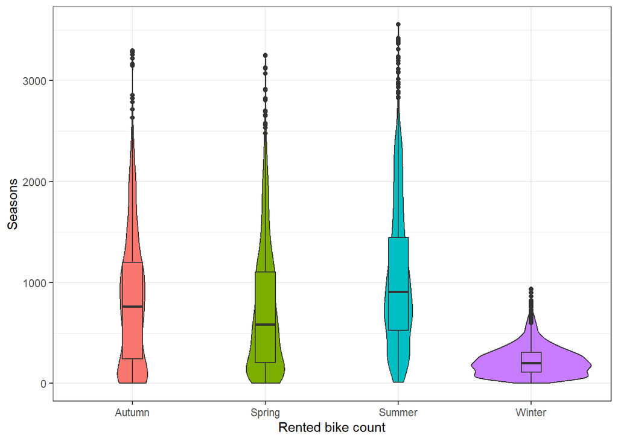

```r
ggplot(data, aes(x = seasons, y = rented_bike_count, fill = seasons)) +
  geom_violin() +
  geom_boxplot(width = 0.15) +
  labs(x = "Rented bike count", y = "Seasons") +
  theme_bw() +
  theme(legend.position = "none")
```

```r
#library(lmPerm)

#set.seed(56)
#out_aov_1 <- aovp(formula = seasons ~ rented_bike_count, data = data, perm = "Prob")
#summary(out_aov_1)
```

## 5.3 Ngày trong tuần.

```r
# Thực hiện nhóm dữ liệu theo 'day_of_week' và tính toán các giá trị
summary_seasons <- data %>%
  group_by(day_of_week) %>%
  summarise(
    n = n(),
    mean_rented_bike_count = mean(rented_bike_count, na.rm = TRUE),
    sd_rented_bike_count = sd(rented_bike_count, na.rm = TRUE)
  )
print(summary_seasons)
```

```
## # A tibble: 7 × 4
##   day_of_week     n mean_rented_bike_count sd_rented_bike_count
##   <chr>       <int>                  <dbl>                <dbl>
## 1 Friday       1272                   747.                 658.
## 2 Monday       1248                   731.                 665.
## 3 Saturday     1248                   710.                 604.
## 4 Sunday       1248                   625.                 606.
## 5 Thursday     1248                   691.                 642.
## 6 Tuesday      1248                   688.                 652.
## 7 Wednesday    1248                   740.                 678.
```

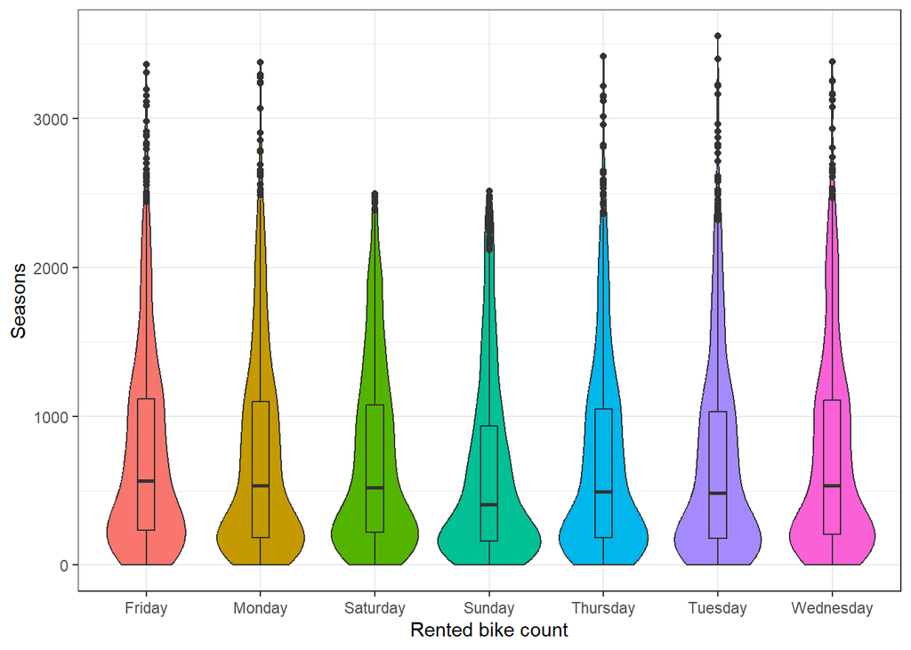

```r
ggplot(data, aes(x = day_of_week, y = rented_bike_count, fill = day_of_week)) +
  geom_violin() +
  geom_boxplot(width = 0.15) +
  labs(x = "Rented bike count", y = "Seasons") +
  theme_bw() +
  theme(legend.position = "none")
```

# 6. Model